# Pandemic Preparedness and COVID-19 Mortality

Amal Surmawala, Nour Abdelmoneim & Rishit Saxena

```r
knitr::opts_chunk$set(echo = TRUE)
```

```r
covid_data <- read.csv("https://wzb-ipi.github.io/corona/df_full.csv")

library(tidyverse)
library(glue)
library(lubridate)
library(rms)
```

```r
library(ggplot2)
library(Rcpp)
library(brms)
library(dplyr)
```

# Introduction

Taking the world by storm in late 2019, the coronavirus pandemic has had (and continues to have) significant social and economic impacts on countries around the world. In the midst of trying to cope with this new public health crisis, data scientists and statisticians have developed models and ran analyses to try and predict which policies will have an effect on reducing the risks of the pandemic. It is also worth analysing the effect of specific variables on nations’ abilities to deal with the virus, something which will hopefully lead to a better understanding of what courses of action can be taken to reduce the number of cases and deaths resulting from COVID-19.

Our intention was to analyse the pandemic preparedness variable in the corona dataset from this GitHub file (https://wzb-ipi.github.io/corona/df_full.csv). The pandemic preparedness variable in the corona dataset we used is taken from the Global Health Security Index (GHSI). The GHSI takes into account factors such as the ability of countries to prevent, detect and respond rapidly to an epidemic. It also considers the capacity of the healthcare system within the country to deal with the strains of pandemics like COVID-19, as well as the country’s commitment to international norms and how ‘risky’ an environment each country poses to the spread of pandemics. We hypothesized that the higher the pandemic preparedness score of the country in question, the lower the number of cumulative deaths per million in the nation. Upon visualizing the data, however, we were faced with unexpected results.

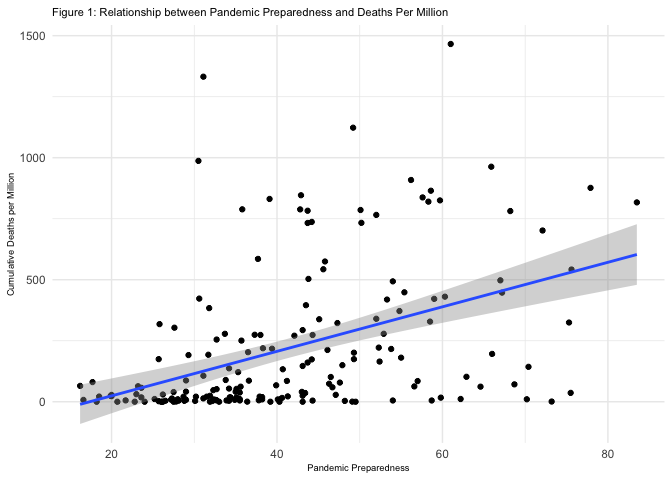

```r
covid_data %>%
  filter(date == "2020-11-30") %>%
  ggplot(covid_data, mapping = aes(x = pandemic_prep, y = deaths_cum_per_million)) +
  geom_point() +
  stat_smooth(method = "lm") +
  labs(title = "Figure 1: Relationship between Pandemic Preparedness and Deaths Per Million",
       x = "Pandemic Preparedness",
       y = "Cumulative Deaths per Million") +
  theme_minimal() +
   theme(title = element_text(size = 7))
```

Contrary to our expectations, the visualization showed that as the pandemic preparedness scores of the nations in the dataset increased, so did the number of cumulative deaths per million. Noting this trend, and acknowledging its contradiction of our initial hypothesis, we decided to adjust our research question and approach to deal with the results we had seen. Thus, our final research question is: why does the number of cumulative deaths per million increase as the pandemic preparedness score rises? How can we explain the fact that countries with high pandemic preparedness scores also had higher numbers of cumulative deaths per million?

This paper will attempt to answer these questions and explain the trends found in our preliminary research by considering confounding variables such as air travel, age, and mean mobility index.

# Theory

The GHSI incorporates a variety of variables to measure the pandemic preparedness of the countries it scores, including “social, political, technical and environmental determinants of health security” (Ravi et al. 3). The use of publicly available data and evidence to account for scores, in addition, lends it a level of transparency and reliability (Ravi et al. 5). Even so, criticism has been levelled at the index for excluding variables of importance and “inadequately weighting others that could more accurately capture the likely response of countries in such an emergency as COVID-19” (Haider et al. 7). Such criticism suggests that it is entirely possible that the GHSI does not account for some variables that may specifically affect the cumulative deaths per million as a result of COVID-19. This paper attempts to identify, therefore, some of the confounding variables that may explain the counter-intuitive relationship seen in the plot above between pandemic preparedness and cumulative deaths per million.

In their analysis of the GHSI, Boyd et al. noted that one factor associated with higher GHSI scores was GDP per capita (6). This relationship can be seen from the figure 2, which demonstrates that countries with higher GDPs per capita tend to have higher pandemic preparedness scores.

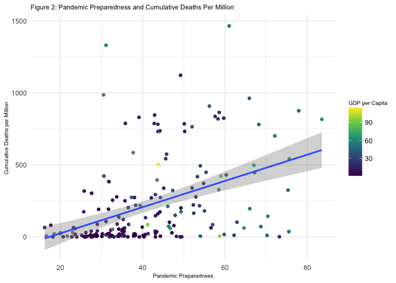

```r
covid_data %>%
  filter(date == "2020-11-30") %>%
  ggplot(covid_data, mapping = aes(x = pandemic_prep, y = deaths_cum_per_million, color = gdp_pc)) +
  scale_color_viridis_c() +
  geom_point() +
  stat_smooth(method = "lm") +
  labs(title = "Figure 2: Pandemic Preparedness and Cumulative Deaths Per Million",
       x = "Pandemic Preparedness",
       y = "Cumulative Deaths per Million",
       color = "GDP per Capita") +
  theme_minimal()+
  theme(title = element_text(size = 7))
```

The association between wealth and the GHSI score suggested to us a possible confounding variable: air travel. Scholars have argued that demand for international air travel is determined, at least partially, by the wealth of consumers. Analysis conducted by the Centre for Aviation concludes that the wealth of a country and air travel are closely correlated - the number of airline seats per capita tends to be higher for countries with higher GDPs per capita (“Air Travel Rises with a Country’s Wealth”).

```
## Warning: Removed 74 rows containing non-finite values (stat_smooth).
```

```
## Warning: Removed 74 rows containing missing values (geom_point).
```

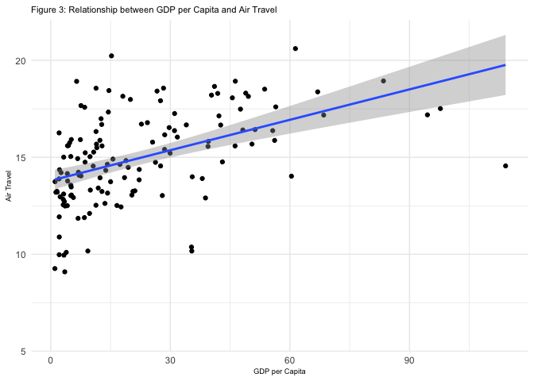

```r
covid_data %>%
  filter(date == "2020-11-30") %>%
  ggplot(covid_data, mapping = aes(x = gdp_pc, y = air_travel)) +
  geom_point() +
  stat_smooth(method = "lm") +
  labs(title = "Figure 3: Relationship between GDP per Capita and Air Travel",
       y = "Air Travel",
       x = "GDP per Capita") +
  theme_minimal()+
  theme(title = element_text(size = 7))
```

As the figure 3 shows, and the analysis by the Centre for Aviation indicates, the level of air travel rises as the GDP per capita of a country increases. Alperovich and Machnes’ case study of the relationship between consumer wealth and demand for international air travel in Israel finds support for the view that demand for air travel rises as consumer wealth does (169). Wealthier countries, in other words, tend to have greater levels of air travel because consumers have enough disposable income to afford flights both domestically and internationally. Given the relationship between wealth and air travel, as well as that between GDP per capita and GHSI pandemic preparedness scores, we theorize that air travel is a confounding variable that could explain the relationship we noticed upon initially visualizing pandemic preparedness and cumulative deaths per million. In other words, countries with higher pandemic preparedness scores also tend to be wealthier, which means that they are more likely to have higher levels of air travel. Due to the fact that the level of air travel is greater in these nations, transmission of the virus across boundaries is made easier, leading to a higher number of COVID-19 cases and overall coronavirus deaths in wealthier countries.

Another possible confounding variable is age. Wealthier nations tend to have higher proportions of people aged above 65 (Tirrito qtd in Crampton 4). The CDC warns that the elderly are at greater risk of requiring hospitalization for and dying from COVID-19 (“Older Adults and COVID-19”). Given that higher pandemic preparedness scores tend to be granted to wealthier nations, and that COVID-19 is reported to pose a greater risk to older adults, we theorized that the nations with higher pandemic preparedness scores also had ageing populations that were more at susceptible to the virus, and therefore saw higher cumulative deaths per million.

```
## Warning: Removed 23732 rows containing non-finite values (stat_smooth).
```

```
## Warning: Removed 23732 rows containing missing values (geom_point).
```

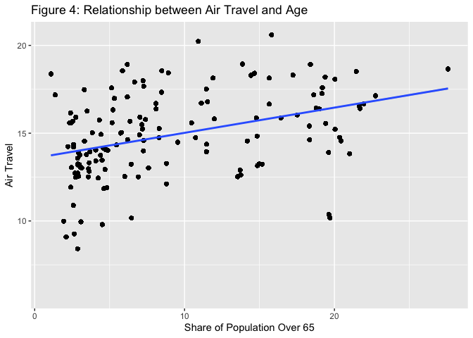

```r
ggplot(covid_data, mapping = aes(x = share_older, y = air_travel)) +
  geom_point() +
  stat_smooth(method = "lm") +
  labs(title = "Figure 4: Relationship between Air Travel and Age",
       x = "Share of Population Over 65",
       y = "Air Travel")
```

Figure 4 shows that the level of air travel increases as the share of the population above 65 rises. Population ageing has led to an increase in interest by researchers and economists on the travel behaviour of seniors and the market for older adults in the tourism industry (Nielsen 111). One theory is that older persons have more free time for leisure and travel because of fewer obligations after retirement and family responsibilities as their children may have already left home, which may explain the positive correlation shown above between air travel and the share of the population above 65, though admittedly they may face travel constraints in the form of low income or health issues (Nielsen 115).

The final confounding variable we chose to consider for our paper is mean mobility index. Li et al. report in their article “Association Between Population Mobility Reductions and New COVID-19 Diagnoses in the United States Along the Urban–Rural Gradient” that reductions in population mobility may act to constrain the growth rate of COVID-19 cases. As such, we decided to consider the mean mobility index as a potential confounding variable. We theorize that countries with a higher mean mobility value would also have a higher number of cumulative deaths per million, as greater mobility of populations may lead to a more rapid spread of the virus and so a rise in the overall number of cases and deaths.

Thus, our hypothesis is that once we account for air travel, age, and mean mobility, we will see a change in the relationship between pandemic preparedness and cumulative deaths per million as seen in the original visualization. More specifically, we hypothesize that the correlation between pandemic preparedness and higher cumulative deaths per million will decrease.

# Data

All the data we used to test our hypothesis comes from this GitHub file (https://wzb-ipi.github.io/corona/df_full.csv) from the paper “Political and Social Correlates of Covid-19 Mortality”, as introduced above. The data on GDP per capita is taken from the World Bank. The air travel variable measures the air passengers carried in both domestic and international aircrafts. The source for the data is also the World Bank. The age variable we chose is the share_older column of the corona dataset (similarly taken from World Bank) that estimates the share of the population over 65. We use the mobility data provided by downloaded from the Google database that our coronavirus dataset contained. The mobility index shows how visits and lengths of stay at different places (e.g. grocery stores) changes according to a baseline.

## Limitations

The first limitation we encountered with our data is the lack of reporting of COVID-19 deaths. The quality and integrity of reporting COVID-19 deaths varies between countries, and since we are doing a worldwide analysis and comparing different countries, that variation had a considerable effect on our data and, ultimately, results. For example, England only counted deaths in hospitals (excluding care home deaths) until April 29th, whereas France and Belgium included care-home deaths from the beginning (Reuben, 2020).

Another limitation was the lack of a standardized system to attribute one’s cause of death to COVID. Attributing the cause of death to COVID is a complicated process between countries; some countries only count a death as a COVID death if the person had a positive COVID test result, whereas others rely on doctors’ opinions (Reuben, 2020). Moreover, many COVID deaths particularly early on in the pandemic were attributed to other causes such as pneumonia. For those reasons, the actual number of COVID deaths is predicted to be much higher than the number of reported deaths that we had

Testing is not as accessible in some countries than it is for others. As mentioned earlier, in many countries, in order for a death to be considered a COVID death, the person would need to have had a positive COVID test result within a specific time range. That means that in countries where testing is not as accessible, reported COVID deaths might be much lower than the actual number of COVID related deaths.

# Methods

To determine why we obtained the unexpected positive slope correlation between pandemic preparedness and cumulative deaths per million, we decided to introduce air travel, age, and mean mobility as confounding variables. First, we generated two plots with respect to each variable. One of the plots compared the variable to cumulative deaths per million to check the relation between the variable and its direct impact on cumulative death per million figures. The second plot we generated for each of the variables was the same initial pandemic preparedness vs cumulative deaths per million plot from the introduction, but this time with the confounding variable mapped to the color aesthetic. This plot helps us to check if there are any visible discernible patterns between the confounding variable we selected and the positive relation between pandemic preparedness and cumulative deaths per million.

To further substantiate possible trends, we ran pandemic preparedness and cumulative deaths per million along with different combinations of chosen confounding variables through a linear regression model to find out about the slope coefficient of these different relations. A one point increase in slope coefficient of a pandemic preparedness and cumulative deaths per million plot directly translates to an increase in cumulative deaths per by a factor of the value x coordinate of that point. We can use this change in the slope coefficient to measure how much of a role different confounding variables played in causing the positive correlation between pandemic preparedness and cumulative deaths per million, and draw conclusions from it.

# Analysis and Interpretation of Results

### Air Travel

The first confounding variable that was considered in our research is air travel. Countries with higher pandemic preparedness generally have a higher air travel rate due to having higher GDPs. Air travel has been proven to be a significant factor that heavily contributes to the spread of COVID cases, and ultimately deaths (Lau et al., 2020).

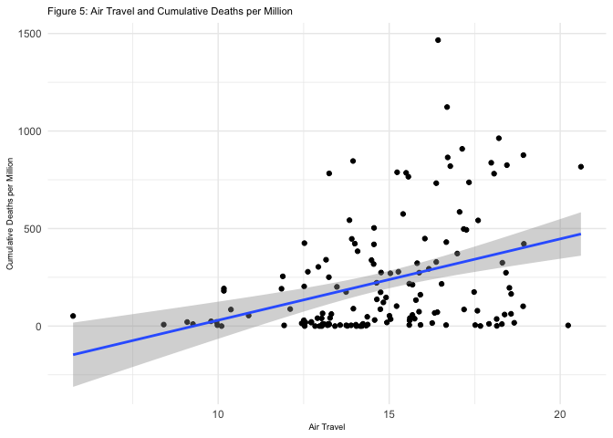

```r
covid_data %>%
  filter(date == "2020-11-30") %>%
  ggplot(covid_data, mapping = aes(x = air_travel, y = deaths_cum_per_million)) +
  geom_point() +
  stat_smooth(method = "lm") +
  labs(title = "Figure 5: Air Travel and Cumulative Deaths per Million",
       x = "Air Travel",
       y = "Cumulative Deaths per Million") +
  theme_minimal() +
  theme(title = element_text(size = 7))
```

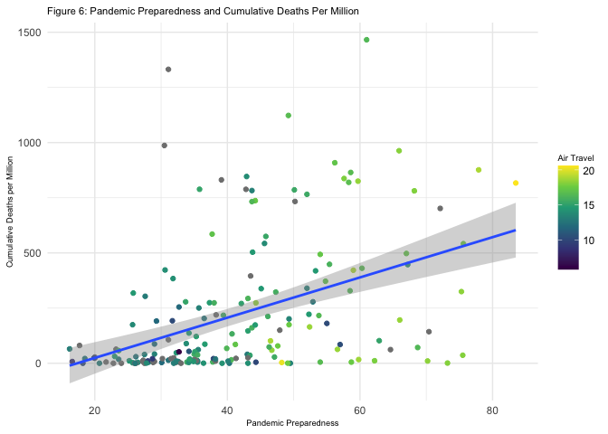

```r
covid_data %>%
  filter(date == "2020-11-30") %>%
  ggplot(covid_data, mapping = aes(x = pandemic_prep, y = deaths_cum_per_million, color = air_travel)) +
  scale_color_viridis_c() +
  geom_point() +
  stat_smooth(method = "lm") +
  labs(title = "Figure 6: Pandemic Preparedness and Cumulative Deaths Per Million",
       x = "Pandemic Preparedness",
       y = "Cumulative Deaths per Million",
       color = "Air Travel") +
  theme_minimal()+
  theme(title = element_text(size = 7))
```

Since no strong conclusions can be drawn from figure 6 alone, we fit a multivariate linear model (with variables air travel, pandemic preparedness, and cumulative COVID deaths per million) in order to observe if the correlation between pandemic preparedness and deaths would decrease when air travel is introduced as a confounding variable.

```r
last_covid_data <- covid_data %>%
  filter(date == "2020-11-30")
```

```r
b1 <-
  brm(data = last_covid_data,
      formula = deaths_cum_per_million ~ 1 + pandemic_prep,
      seed = 5,
      )
summary(b1)
```

```
##  Family: gaussian
##   Links: mu = identity; sigma = identity
## Formula: deaths_cum_per_million ~ 1 + pandemic_prep
##    Data: last_covid_data (Number of observations: 183)
## Samples: 4 chains, each with iter = 2000; warmup = 1000; thin = 1;
##          total post-warmup samples = 4000
##
## Population-Level Effects:
##               Estimate Est.Error l-95% CI u-95% CI Rhat Bulk_ESS Tail_ESS
## Intercept      -164.38     61.55  -284.59   -41.97 1.00     4002     2761
## pandemic_prep     9.15      1.40     6.36    11.87 1.00     3767     2974
##
## Family Specific Parameters:
##       Estimate Est.Error l-95% CI u-95% CI Rhat Bulk_ESS Tail_ESS
## sigma   271.61     14.35   245.17   301.47 1.00     3818     2968
##
## Samples were drawn using sampling(NUTS). For each parameter, Bulk_ESS
## and Tail_ESS are effective sample size measures, and Rhat is the potential
## scale reduction factor on split chains (at convergence, Rhat = 1).
```

```r
b2 <-
  brm(data = last_covid_data,
      formula = deaths_cum_per_million ~ 1 + air_travel + pandemic_prep,
      seed = 5,
      )
summary(b2)
```

```
##  Family: gaussian
##   Links: mu = identity; sigma = identity
## Formula: deaths_cum_per_million ~ 1 + air_travel + pandemic_prep
##    Data: last_covid_data (Number of observations: 145)
## Samples: 4 chains, each with iter = 2000; warmup = 1000; thin = 1;
##          total post-warmup samples = 4000
##
## Population-Level Effects:
##               Estimate Est.Error l-95% CI u-95% CI Rhat Bulk_ESS Tail_ESS
## Intercept      -315.11    126.72  -567.44   -65.71 1.00     4635     3368
## air_travel       13.00     10.84    -8.05    34.33 1.00     3424     3019
## pandemic_prep     8.06      2.01     4.19    12.07 1.00     3229     2813
##
## Family Specific Parameters:
##       Estimate Est.Error l-95% CI u-95% CI Rhat Bulk_ESS Tail_ESS
## sigma   259.15     15.22   231.30   291.47 1.00     3171     2217
##
## Samples were drawn using sampling(NUTS). For each parameter, Bulk_ESS
## and Tail_ESS are effective sample size measures, and Rhat is the potential
## scale reduction factor on split chains (at convergence, Rhat = 1).
```

### Age

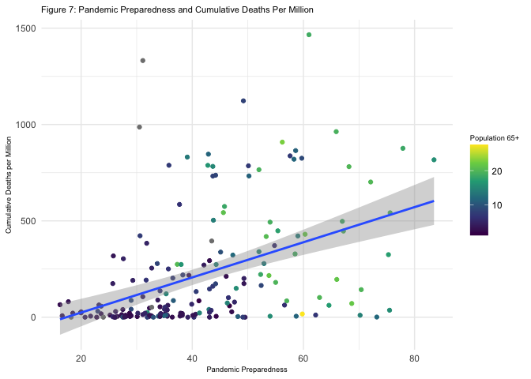

```r
covid_data %>%
  filter(date == "2020-11-30") %>%
  ggplot(covid_data, mapping = aes(x = pandemic_prep, y = deaths_cum_per_million, color = share_older)) +
  scale_color_viridis_c() +
  geom_point() +
  stat_smooth(method = "lm") +
  labs(title = "Figure 7: Pandemic Preparedness and Cumulative Deaths Per Million",
       x = "Pandemic Preparedness",
       y = "Cumulative Deaths per Million",
       color = "Population 65+") +
  theme_minimal() +
   theme(title = element_text(size = 7))
```

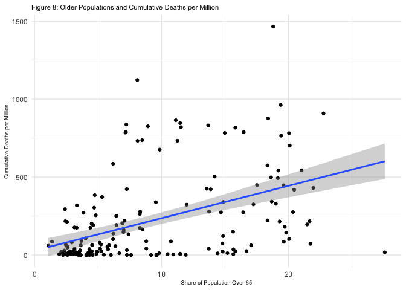

```r
covid_data %>%
  filter(date == "2020-11-30") %>%
  ggplot(covid_data, mapping = aes(x = share_older, y = deaths_cum_per_million)) +
  geom_point() +
  stat_smooth(method = "lm") +
  labs(title = "Figure 8: Older Populations and Cumulative Deaths per Million",
       x = "Share of Population Over 65",
       y = "Cumulative Deaths per Million") +
  theme_minimal() +
  theme(title = element_text(size = 7))
```

To build on the patterns we saw in figures 7 and 8, we once again rely on the multivariate linear model(age replacing air travel) to find out the new correlation between pandemic preparedness and cumulative deaths per million when age as a confounding variable.

As shown below, with age as a confounding variable, the correlation between pandemic preparedness and cumulative deaths per million falls from 9.13 to 5.84. In addition, the lower range of uncertainty decreases from 6.29 to 2.06. This steep drop off in correlation and uncertainty suggests that age did play a very significant role in the high positive correlation that we initially observed.

```r
b3 <-
  brm(data = last_covid_data,
      formula = deaths_cum_per_million ~ 1 + pandemic_prep + share_older,
      seed = 5,
      )
summary(b3)
```

```
##  Family: gaussian
##   Links: mu = identity; sigma = identity
## Formula: deaths_cum_per_million ~ 1 + pandemic_prep + share_older
##    Data: last_covid_data (Number of observations: 176)
## Samples: 4 chains, each with iter = 2000; warmup = 1000; thin = 1;
##          total post-warmup samples = 4000
##
## Population-Level Effects:
##               Estimate Est.Error l-95% CI u-95% CI Rhat Bulk_ESS Tail_ESS
## Intercept      -140.62     60.51  -257.92   -20.84 1.00     3864     3240
## pandemic_prep     5.72      1.83     2.14     9.25 1.00     2892     2719
## share_older      12.50      4.13     4.03    20.51 1.00     2909     2548
##
## Family Specific Parameters:
##       Estimate Est.Error l-95% CI u-95% CI Rhat Bulk_ESS Tail_ESS
## sigma   246.94     13.13   223.31   274.39 1.00     3972     2778
##
## Samples were drawn using sampling(NUTS). For each parameter, Bulk_ESS
## and Tail_ESS are effective sample size measures, and Rhat is the potential
## scale reduction factor on split chains (at convergence, Rhat = 1).
```

Furthermore, when we add air travel back to the model while retaining age, we observe a decrease in correlation from the initial 9.13 to 3.61 with the lower range of uncertainty being -1.35. This supports both our previous claims that air travel and age played a role in the unanticipated initial plots that we obtained.

```r
b4 <-
  brm(data = last_covid_data,
      formula = deaths_cum_per_million ~ 1 + pandemic_prep + share_older + air_travel,
      seed = 5,
      )
summary(b4)
```

```
##  Family: gaussian
##   Links: mu = identity; sigma = identity
## Formula: deaths_cum_per_million ~ 1 + pandemic_prep + share_older + air_travel
##    Data: last_covid_data (Number of observations: 143)
## Samples: 4 chains, each with iter = 2000; warmup = 1000; thin = 1;
##          total post-warmup samples = 4000
##
## Population-Level Effects:
##               Estimate Est.Error l-95% CI u-95% CI Rhat Bulk_ESS Tail_ESS
## Intercept      -306.07    139.55  -573.21   -30.37 1.00     4122     3570
## pandemic_prep     3.59      2.58    -1.40     8.67 1.00     2373     2374
## share_older      12.81      4.50     4.05    21.81 1.00     3121     2805
## air_travel       17.58     12.01    -6.04    41.49 1.00     2917     2852
##
## Family Specific Parameters:
##       Estimate Est.Error l-95% CI u-95% CI Rhat Bulk_ESS Tail_ESS
## sigma   254.86     15.55   226.30   286.65 1.00     3962     2765
##
## Samples were drawn using sampling(NUTS). For each parameter, Bulk_ESS
## and Tail_ESS are effective sample size measures, and Rhat is the potential
## scale reduction factor on split chains (at convergence, Rhat = 1).
```

### Mean Mobility Index

Another factor that could be contributing to higher COVID deaths in different countries is mobility index. Since mobility index is a measure that changes daily, we decided to take the mean mobility index for each country since the start of the pandemic up to November 30th, and examine how mean mobility index affected cumulative COVID deaths per million (also up to November 30th) for each country.

```r
groupedData <- covid_data %>%
  filter(elapsed > 60, mobility_index!= "NA") %>%
  group_by(country)

groupedData <- groupedData %>%
  summarise(mean_mobility = mean(mobility_index))
new_covid_data <- merge(covid_data,groupedData,by="country")
```

Before beginning our analysis, there are a few limitations worth mentioning about using mean mobility index for this research. First, the mean mobility index does not represent the change of mobility over time and how that affected COVID deaths in each country. In fact, figure 9 shows that countries with higher cumulative deaths actually had lower mean mobility indexes. That could be because the countries that experienced a very high number of deaths from the beginning of the pandemic, implemented stricter lockdown measures and decreased their mobility. Despite these limitations, we wanted to analyze the effects of adding mean mobility to our linear model on the relationship between pandemic preparedness and cumulative COVID deaths per million.

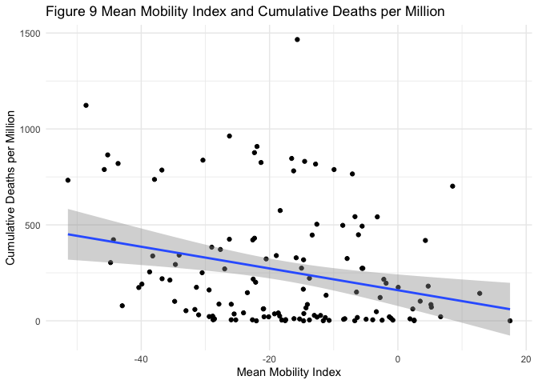

```r
new_covid_data %>%
  filter(date == "2020-11-30") %>%
  ggplot(covid_data, mapping = aes(x = mean_mobility, y = deaths_cum_per_million)) +
  geom_point() +
  stat_smooth(method = "lm") +
  labs(title = "Figure 9 Mean Mobility Index and Cumulative Deaths per Million",
       x = "Mean Mobility Index",
       y = "Cumulative Deaths per Million") +
  theme_minimal()
```

As shown below, controlling for mean mobility index (without other confounding variables - age and air travel) reduced the positive correlation between pandemic preparedness and COVID deaths by over 50% (9.13 to 4.38).

```r
b5 <-
  brm(data = new_covid_data,
      formula = deaths_cum_per_million ~ 1 + mean_mobility + pandemic_prep,
      seed = 5,
      )
summary(b5)
```

```
##  Family: gaussian
##   Links: mu = identity; sigma = identity
## Formula: deaths_cum_per_million ~ 1 + mean_mobility + pandemic_prep
##    Data: new_covid_data (Number of observations: 44672)
## Samples: 4 chains, each with iter = 2000; warmup = 1000; thin = 1;
##          total post-warmup samples = 4000
##
## Population-Level Effects:
##               Estimate Est.Error l-95% CI u-95% CI Rhat Bulk_ESS Tail_ESS
## Intercept      -158.36      3.00  -164.13  -152.45 1.00     3325     3082
## mean_mobility    -2.55      0.06    -2.66    -2.44 1.00     3556     2819
## pandemic_prep     4.38      0.06     4.26     4.49 1.00     3625     3019
##
## Family Specific Parameters:
##       Estimate Est.Error l-95% CI u-95% CI Rhat Bulk_ESS Tail_ESS
## sigma   168.49      0.56   167.40   169.59 1.00     4717     3112
##
## Samples were drawn using sampling(NUTS). For each parameter, Bulk_ESS
## and Tail_ESS are effective sample size measures, and Rhat is the potential
## scale reduction factor on split chains (at convergence, Rhat = 1).
```

Moreover, combining mean mobility with the previous multivariate linear model (with air travel and age), results in an even lower correlation between pandemic preparedness and COVID deaths (2.38), which suggests that mobility could have been one of the factors contributing to the unexpected relationship between pandemic preparedness and COVID deaths.

```r
b6 <-
  brm(data = new_covid_data,
      formula = deaths_cum_per_million ~ 1 + mean_mobility + pandemic_prep + air_travel + share_older,
      seed = 5,
      )
summary(b6)
```

```
##  Family: gaussian
##   Links: mu = identity; sigma = identity
## Formula: deaths_cum_per_million ~ 1 + mean_mobility + pandemic_prep + air_travel + share_older
##    Data: new_covid_data (Number of observations: 39437)
## Samples: 4 chains, each with iter = 2000; warmup = 1000; thin = 1;
##          total post-warmup samples = 4000
##
## Population-Level Effects:
##               Estimate Est.Error l-95% CI u-95% CI Rhat Bulk_ESS Tail_ESS
## Intercept      -192.02      5.98  -203.78  -180.40 1.00     3976     3471
## mean_mobility    -3.18      0.07    -3.31    -3.05 1.00     3594     2646
## pandemic_prep     2.33      0.10     2.12     2.53 1.00     2531     2827
## air_travel        4.38      0.53     3.36     5.44 1.00     2804     2782
## share_older       4.86      0.18     4.52     5.20 1.00     2795     3119
##
## Family Specific Parameters:
##       Estimate Est.Error l-95% CI u-95% CI Rhat Bulk_ESS Tail_ESS
## sigma   169.70      0.60   168.54   170.91 1.00     6961     2892
##
## Samples were drawn using sampling(NUTS). For each parameter, Bulk_ESS
## and Tail_ESS are effective sample size measures, and Rhat is the potential
## scale reduction factor on split chains (at convergence, Rhat = 1).
```

# Conclusions

From the previous analysis alone, no strong conclusions can be drawn about how pandemic preparedness affects COVID 19 mortality around the world because there seems to be a range of other factors that need to be taken into account before coming to that conclusion.

However, what we can conclude is that air travel and age were definitely two factors contributing to the counterintuitive relationship between pandemic preparedness and cumulative COVID-19 deaths per million. Additionally, it is also likely that mobility index played a role, however, we cannot state that with certainty considering the limitations of using the mean mobility index. Further analysis of the evolution of mobility index and COVID deaths over time would help define that relationship with more certainty.

For a further analysis, other factors such as government stringency, lockdown measures, and population density can be examined to analyze their contributions to the relationship between pandemic preparedness and COVID-19 deaths. That would allow us to further understand the effect pandemic preparedness had on COVID mortality and draw stronger conclusions about the relationship between the two variables.

# Works Cited

“Air Travel Rises with a Country’s Wealth. Law of Nature, or Can Government Policy Make a Difference?” Centre for Aviation , 1 June 2014, centreforaviation.com/analysis/reports/air-travel-rises-with-a-countrys-wealth-law-of-nature-or-can-government-policy-make-a-difference-170674.

Alperovich, Gershon, and Yaffa Machnes. “The Role of Wealth in the Demand for International Air Travel.” Journal of Transport Economics and Policy, vol. 28, no. 2, 1994, pp. 163–173. JSTOR, www.jstor.org/stable/20053033. Accessed 13 Dec. 2020.

Boyd, Matthew J, Wilson, Nick, Nelson, Cassidy. “Validation analysis of Global Health Security Index (GHSI) scores 2019.” BMJ Global Health, vol. 5, issue 10, 2020. http://dx.doi.org/10.1136/bmjgh-2020-003276.

Campton, Alexandra. “Global Ageing: Emerging Challenges.” The Pardee Papers, no. 6, August 2009, pp. 1-39. https://www.bu.edu/pardee/files/2009/09/pardee_aging-6-global-aging.pdf

Haider, Najmul, et al. “The Global Health Security Index and Joint External Evaluation Score for Health Preparedness Are Not Correlated with Countries’ COVID-19 Detection Response Time and Mortality Outcome.” Epidemiology and Infection, vol. 148, 2020. doi:10.1017/S0950268820002046.

Lau, H., Khosrawipour, V., Kocbach, P., Mikolajczyk, A., Ichii, H., Zacharski, M., . . . Khosrawipour, T. (2020). The association between international and domestic air traffic and the coronavirus (COVID-19) outbreak. Journal of Microbiology, Immunology and Infection, 53(3), 467-472. doi:10.1016/j.jmii.2020.03.026

Li, Xiaojiang, Rudolph, Abby E., Mennis, Jeremy. “Association Between Population Mobility Reductions and New COVID-19 Diagnoses in the United States Along the Urban–Rural Gradient, February-April 2020” Centers for Disease Control and Prevention, October 2020. https://www.cdc.gov/pcd/issues/2020/20_0241.htm, DOI: http://dx.doi.org/10.5888/pcd17.200241.

Nielsen, Karina. “Approaches to Seniors’ Tourist Behaviour.” Tourism Review of AIEST - International Association of Scientific Experts in Tourism, vol. 69, no. 2, 2014, pp. 111-121. ProQuest, http://proxy.library.nyu.edu/login?url=https://www-proquest-com.proxy.library.nyu.edu/scholarly-journals/approaches-seniors-tourist-behaviour/docview/1652829639/se-2?accountid=12768, doi:http://dx.doi.org.proxy.library.nyu.edu/10.1108/TR-05-2013-0021.

“Older Adults and COVID-19.” Centers for Disease Control and Prevention, Centers for Disease Control and Prevention, 2020, www.cdc.gov/coronavirus/2019-ncov/need-extra-precautions/older-adults.html.

Ravi, Sanjana J, Warmbrod, Kelsey L, Mullen, Lucia, et al. “The value proposition of the Global Health Security Index.” BMJ Global Health, vol. 5, issue 10, 2020. http://dx.doi.org/10.1136/bmjgh-2020-003648.

Reuben, C. (2020, June 17). Coronavirus: Why are international comparisons difficult? Retrieved November 30, 2020, from https://www.bbc.com/news/52311014

Ying, Kejun, et al. “Genetic and Phenotypic Evidence for the Causal Relationship Between Aging and COVID-19.” MedRxiv, Cold Spring Harbor Laboratory Press, Oct. 2020, p. 2020.08.06.20169854. www.medrxiv.org, doi:10.1101/2020.08.06.20169854.

Miladinov, Goran. “Socioeconomic Development and Life Expectancy Relationship: Evidence from the EU Accession Candidate Countries.” Genus, vol. 76, no. 1, Jan. 2020, p. 2. BioMed Central, doi:10.1186/s41118-019-0071-0.